# Assignment 2

Author

Sylwia Lipior

# **Data Wrangling**

## Download the data

```r
# Download the data from Github

download.file(

    "https://raw.githubusercontent.com/USCbiostats/data-science-data/master/01_chs/chs_individual.csv",

    destfile = "chs_individual.csv",

    method   = "libcurl",

    timeout  = 60 )

chs_individual <- data.table::fread("chs_individual.csv")

download.file(

    "https://raw.githubusercontent.com/USCbiostats/data-science-data/master/01_chs/chs_regional.csv",

    destfile = "chs_regional.csv",

    method   = "libcurl",

    timeout  = 60 )

chs_regional <- data.table::fread("chs_regional.csv")
```

## 1.Merge the individual/regional data set and fix all missing values in the data

```r
# Merge the regional and individual data together by townname

# merge two data frames by townname
chs_total <- merge(chs_individual,chs_regional,by="townname")

# Load necessary libraries
library(dplyr)
library(magrittr)

# Check for NA values in the merged_data dataset
na_count_before_cleaning <- colSums(is.na(chs_total))

# Print the number of NA values for each column
print(na_count_before_cleaning)
```

```
     townname           sid          male          race      hispanic
            0             0             0             0             0
       agepft        height        weight           bmi        asthma
           89            89            89            89            31
active_asthma father_asthma mother_asthma        wheeze      hayfever
            0           106            56            71           118
      allergy   educ_parent         smoke          pets      gasstove
           63            64            40             0            33
          fev           fvc          mmef     pm25_mass      pm25_so4
           95            97           106             0             0
     pm25_no3      pm25_nh4       pm25_oc       pm25_ec       pm25_om
            0             0             0             0             0
      pm10_oc       pm10_ec       pm10_tc        formic        acetic
            0             0             0             0             0
          hcl          hno3        o3_max         o3106         o3_24
            0             0             0             0             0
          no2          pm10       no_24hr      pm2_5_fr         iacid
            0             0           100           300             0
        oacid   total_acids           lon           lat
            0             0             0             0
```

```r
# Define a custom mode function for categorical variables
custom_mode <- function(x) {
  unique_values <- unique(x)
  unique_values[which.max(tabulate(match(x, unique_values)))]
}

# Impute missing values
# Impute missing numerical values using the average within groups defined by "male" and "hispanic" variables
numeric_vars <- c("bmi", "fev", "fvc", "height", "mmef", "weight", "agepft", "pm2_5_fr")  # Numeric variable names from your list
chs_total <- chs_total %>%
  group_by(male, hispanic) %>%
  mutate(across(all_of(numeric_vars), ~ifelse(is.na(.), mean(., na.rm = TRUE), .))) %>%
  ungroup()

# Impute missing categorical values using the custom mode function within groups defined by "male" and "hispanic" variables
categorical_vars <- c("active_asthma", "allergy", "asthma", "educ_parent", "father_asthma", "gasstove", "hayfever", "mother_asthma", "no_24hr", "smoke", "wheeze")  # Categorical variable names from your list
for (var in categorical_vars) {
  chs_total <- chs_total %>%
    group_by(male, hispanic) %>%
    mutate(!!var := ifelse(is.na(!!sym(var)), custom_mode(!!sym(var)), !!sym(var))) %>%
    ungroup()
}

# Check for missing values after imputation
missing_values <- sum(is.na(chs_total))
cat("Missing values after imputation:", missing_values, "\n")
```

```
Missing values after imputation: 0
```

```r
# Verify that the number of rows matches your expectation
expected_row_count <-  1200
if (nrow(chs_total) == expected_row_count) {
  cat("Data cleaning and imputation completed successfully.\n")
} else {
  cat("Warning: Row count does not match expectations.\n")
}
```

```
Data cleaning and imputation completed successfully.
```

## 2.Create the obesity_level variable

```r
# create the obesity_level variable

library(dplyr)

# Create the "obesity_level" variable
chs_total <- chs_total %>%
  mutate(
    obesity_level = case_when(
      bmi < 14 ~ "Underweight",
      bmi >= 14 & bmi <= 22 ~ "Normal",
      bmi > 22 & bmi <= 24 ~ "Overweight",
      bmi > 24 ~ "Obese",
      TRUE ~ NA_character_
    )
  )

# Create a summary table
summary_table <- chs_total %>%
  group_by(obesity_level) %>%
  summarise(
    Min_BMI = min(bmi, na.rm = TRUE),
    Max_BMI = max(bmi, na.rm = TRUE),
    Total_Observations = n()
  )

# Print the summary table
print(summary_table)
```

```
# A tibble: 4 × 4
  obesity_level Min_BMI Max_BMI Total_Observations
  <chr>           <dbl>   <dbl>              <int>
1 Normal           14.0    22.0                975
2 Obese            24.0    41.3                103
3 Overweight       22.0    24.0                 87
4 Underweight      11.3    14.0                 35
```

## 3.Create the “smoke_gas_exposure” variable that summarizes “Second Hand Smoke” and “Gas Stove.”

```r
library(dplyr)

# Create the "smoke_gas_exposure" variable
chs_total <- chs_total %>%
  mutate(
    smoke_gas_exposure = case_when(
      smoke == 1 & gasstove == 1 ~ "Both Smoke and Gas",
      smoke == 1 & gasstove == 0 ~ "Smoke Only",
      smoke == 0 & gasstove == 1 ~ "Gas Stove Only",
      smoke == 0 & gasstove == 0 ~ "No Smoke or Gas",
    )
  )

# Create a summary table
summary_table_gas <- chs_total %>%
  group_by(smoke_gas_exposure) %>%
  summarise(
    Count = n()
  )

# Print the summary table
print(summary_table_gas)
```

```
# A tibble: 4 × 2
  smoke_gas_exposure Count
  <chr>              <int>
1 Both Smoke and Gas   154
2 Gas Stove Only       791
3 No Smoke or Gas      219
4 Smoke Only            36
```

## 4. Create four summary tables showing the average (or proportion, if binary) and sd of “Forced expiratory volume in 1 second (ml)” (an asthma indicator) by town, sex, obesity level, and “smoke_gas_exposure.”

```r
# Load the necessary libraries
library(dplyr)

# Summary table by town
town_summary <- chs_total %>%
  group_by(townname) %>%
  summarise(
    Mean_FEV = mean(fev, na.rm = TRUE),
    SD_FEV = sd(fev, na.rm = TRUE)
  )

# Summary table by sex with proportions, mean FEV, and SD FEV for both males and females
sex_summary <- chs_total %>%
  summarise(
    Proportion_Male = mean(male == 1, na.rm = TRUE) * 100,
    Proportion_Female = mean(male == 0, na.rm = TRUE) * 100,  # Calculate the percentage for females
    Mean_FEV_Male = mean(fev[male == 1], na.rm = TRUE),
    Mean_FEV_Female = mean(fev[male == 0], na.rm = TRUE),  # Calculate the mean FEV for females
    SD_FEV_Male = sd(fev[male == 1], na.rm = TRUE),
    SD_FEV_Female = sd(fev[male == 0], na.rm = TRUE)  # Calculate the SD FEV for females
  )

# Summary table by obesity level
obesity_summary <- chs_total %>%
  group_by(obesity_level) %>%
  summarise(
    Mean_FEV = mean(fev, na.rm = TRUE),
    SD_FEV = sd(fev, na.rm = TRUE)
  )

# Summary table by smoke_gas_exposure
smoke_gas_summary <- chs_total %>%
  group_by(smoke_gas_exposure) %>%
  summarise(
    Mean_FEV = mean(fev, na.rm = TRUE),
    SD_FEV = sd(fev, na.rm = TRUE)
  )

# Print the summary tables
print("Summary by Town:")
```

```
[1] "Summary by Town:"
```

```r
print(town_summary)
```

```
# A tibble: 12 × 3
   townname      Mean_FEV SD_FEV
   <chr>            <dbl>  <dbl>
 1 Alpine           2087.   291.
 2 Atascadero       2076.   324.
 3 Lake Elsinore    2039.   304.
 4 Lake Gregory     2085.   320.
 5 Lancaster        2003.   317.
 6 Lompoc           2034.   351.
 7 Long Beach       1986.   319.
 8 Mira Loma        1985.   325.
 9 Riverside        1990.   278.
10 San Dimas        2027.   319.
11 Santa Maria      2026.   312.
12 Upland           2024.   343.
```

```r
print("Summary by Sex (Male and Female):")
```

```
[1] "Summary by Sex (Male and Female):"
```

```r
print(sex_summary)
```

```
# A tibble: 1 × 6
  Proportion_Male Proportion_Female Mean_FEV_Male Mean_FEV_Female SD_FEV_Male
            <dbl>             <dbl>         <dbl>           <dbl>       <dbl>
1            49.2              50.8         2104.           1959.        308.
# ℹ 1 more variable: SD_FEV_Female <dbl>
```

```r
print("Summary by Obesity Level:")
```

```
[1] "Summary by Obesity Level:"
```

```r
print(obesity_summary)
```

```
# A tibble: 4 × 3
  obesity_level Mean_FEV SD_FEV
  <chr>            <dbl>  <dbl>
1 Normal           2000.   295.
2 Obese            2266.   325.
3 Overweight       2224.   317.
4 Underweight      1698.   303.
```

```r
print("Summary by Smoke Gas Exposure:")
```

```
[1] "Summary by Smoke Gas Exposure:"
```

```r
print(smoke_gas_summary)
```

```
# A tibble: 4 × 3
  smoke_gas_exposure Mean_FEV SD_FEV
  <chr>                 <dbl>  <dbl>
1 Both Smoke and Gas    2025.   301.
2 Gas Stove Only        2023.   319.
3 No Smoke or Gas       2057.   329.
4 Smoke Only            2056.   296.
```

# **Looking at the data (EDA)**

## 1.What is the association between BMI and FEV (forced expiratory volume)?

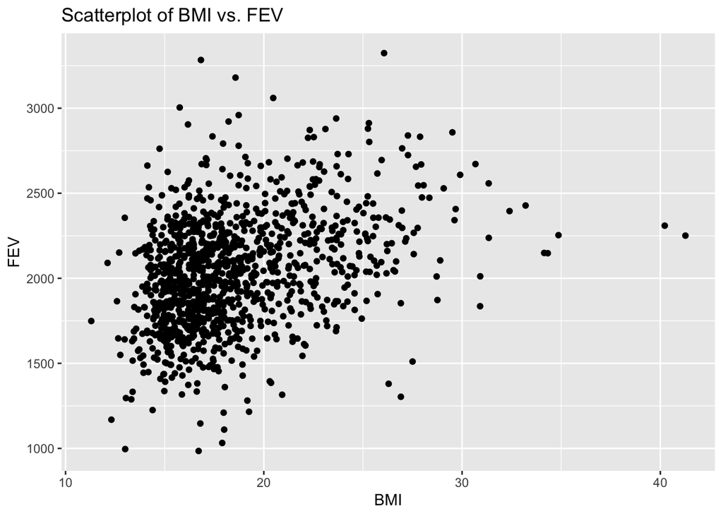

```r
# Load necessary libraries
library(ggplot2)

# Create a scatterplot of BMI vs. FEV
ggplot(chs_total, aes(x = bmi, y = fev)) +
  geom_point() +
  labs(title = "Scatterplot of BMI vs. FEV", x = "BMI", y = "FEV")
```

```r
# Calculate the correlation coefficient
correlation <- cor(chs_total$bmi, chs_total$fev, use = "complete.obs")
print(paste("Correlation coefficient between BMI and FEV:", correlation))
```

```
[1] "Correlation coefficient between BMI and FEV: 0.357112030981777"
```

The correlation coefficient between BMI (body mass index) and FEV (forced expiratory volume) is approximately 0.357.

This positive correlation suggests that there is a moderate positive relationship between BMI and FEV in the dataset. In other words, as BMI tends to increase, FEV also tends to increase. The strength of this association is moderate, indicating that while there is a noticeable trend, BMI alone does not explain the entirety of the variation in FEV. Other factors may also influence lung function, and further analysis or studies may be needed to explore the causal mechanisms underlying this relationship.

## 2.What is the association between smoke and gas exposure and FEV?

```r
#before I was more descriptive in the smoke_gas_exposure variable, but this time it will simply be a 0 or 1
chs_total$smoke_gas_exposure <- (chs_total$smoke == 1 | chs_total$gasstove == 1)

cor(chs_total$smoke_gas_exposure, chs_total$fev)
```

```
[1] -0.03946755
```

```r
model <- lm(fev ~ smoke_gas_exposure, data = chs_total)
summary(model)
```

```
Call:
lm(formula = fev ~ smoke_gas_exposure, data = chs_total)

Residuals:
     Min       1Q   Median       3Q      Max
-1039.37  -205.56   -13.54   192.85  1299.47

Coefficients:
                       Estimate Std. Error t value Pr(>|t|)
(Intercept)             2056.69      21.48  95.748   <2e-16 ***
smoke_gas_exposureTRUE   -32.48      23.76  -1.367    0.172
---
Signif. codes:  0 '***' 0.001 '**' 0.01 '*' 0.05 '.' 0.1 ' ' 1

Residual standard error: 317.9 on 1198 degrees of freedom
Multiple R-squared:  0.001558,  Adjusted R-squared:  0.0007243
F-statistic: 1.869 on 1 and 1198 DF,  p-value: 0.1718
```

The analysis reveals that there is a very weak and statistically insignificant association between exposure to smoke or gas and an individual’s forced expiratory volume (FEV). The correlation coefficient of approximately -0.0395 indicates a negligible linear relationship, and the linear regression model further supports this by showing that exposure to smoke or gas is not a significant predictor of FEV. The coefficient for “smoke_gas_exposureTRUE” suggests a slight decrease in mean FEV for those exposed, but this difference is not statistically significant with a p-value of 0.172. In summary, the data do not support a meaningful connection between smoke or gas exposure and FEV, and other factors likely play a more substantial role in determining lung function.

## 3. What is the association between PM2.5 exposure and FEV?

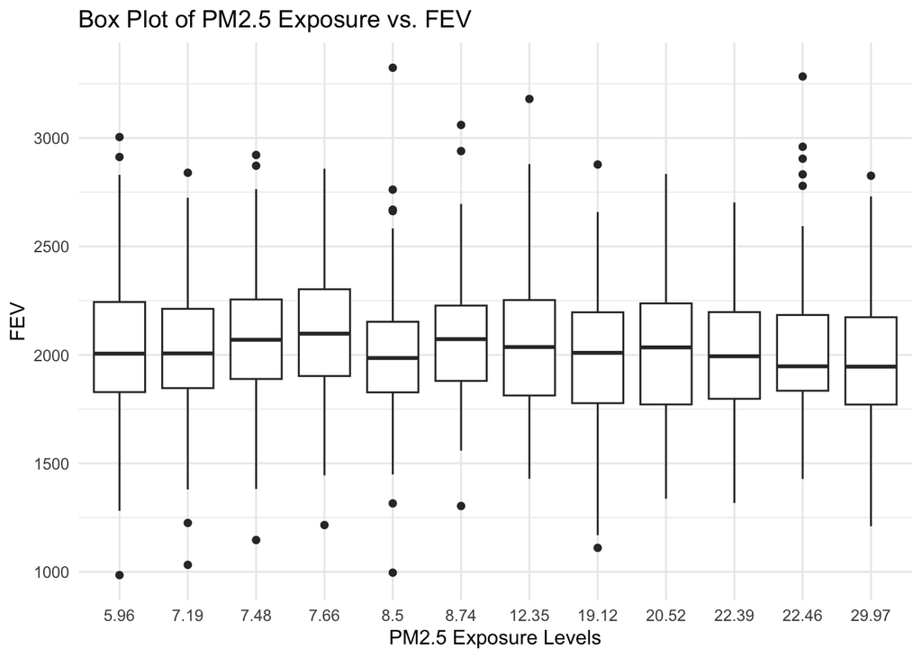

```r
# EDA and Visualization
# Create a box plot to visualize the relationship
ggplot(chs_total, aes(x = factor(pm25_mass), y = fev)) +
  geom_boxplot() +
  labs(title = "Box Plot of PM2.5 Exposure vs. FEV",
       x = "PM2.5 Exposure Levels",
       y = "FEV") +
  theme_minimal()
```

```r
# Correlation Analysis
# Calculate the correlation coefficient
correlation <- cor(chs_total$pm25_mass, chs_total$fev)

# Print the correlation coefficient
cat("Correlation coefficient between PM2.5 exposure and FEV:", correlation)
```

```
Correlation coefficient between PM2.5 exposure and FEV: -0.07341317
```

```r
# Summary Statistics
# Summary statistics for PM2.5 exposure and FEV
summary(chs_total$pm25_mass)
```

```
   Min. 1st Qu.  Median    Mean 3rd Qu.    Max.
  5.960   7.615  10.545  14.362  20.988  29.970
```

```r
summary(chs_total$fev)
```

```
   Min. 1st Qu.  Median    Mean 3rd Qu.    Max.
  984.8  1827.6  2016.4  2030.1  2223.6  3323.7
```

# **Visualization**

## 1.Facet plot showing scatterplots with regression lines of BMI vs FEV by “townname”.

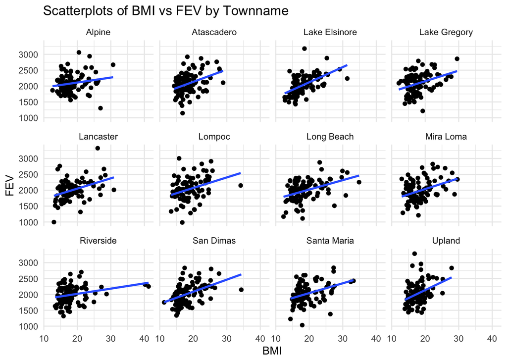

```r
library(ggplot2)

# Create the scatterplot with regression lines
scatterplot <- ggplot(chs_total, aes(x = bmi, y = fev)) +
  geom_point() +  # Scatterplot points
  geom_smooth(method = "lm", se = FALSE) +  # Regression lines without confidence intervals
  labs(title = "Scatterplots of BMI vs FEV by Townname", x = "BMI", y = "FEV") +
  theme_minimal()

# Facet the plot by townname
facet_plot <- scatterplot + facet_wrap(~townname)

# Print the facet plot
print(facet_plot)
```

Interpretation: When looking at FEV vs BMI in each community included in the data, it seems that there is a common trend of a positive linear correlation between FEV and BMI. In other words, when BMI increases, FEV also increases. Most of the communities don’t have too many outliers (besides Riverside, which has a couple data points with unexpectedly high BMI).

## 2. Stacked histograms of FEV by BMI category and FEV by smoke/gas exposure. Use different color schemes than the ggplot default.

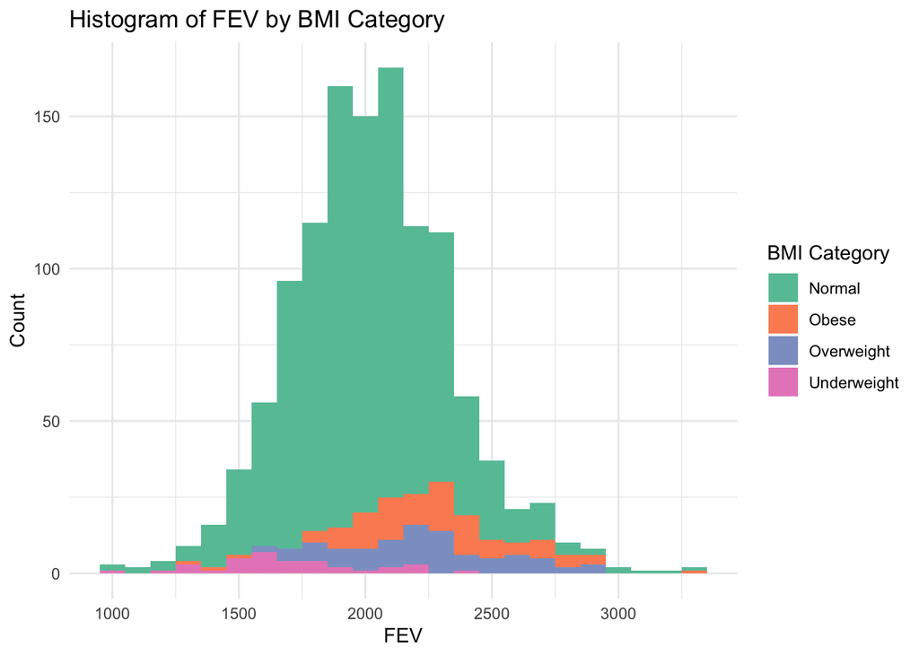

```r
library(ggplot2)

# Convert the "obesity_level" variable to a factor with desired levels
chs_total$obesity_level <- factor(chs_total$obesity_level, levels = c("Normal", "Obese", "Overweight", "Underweight"))

# Create stacked histograms of FEV by BMI category
histogram_bmi <- ggplot(chs_total, aes(x = fev, fill = obesity_level)) +
  geom_histogram(binwidth = 100, position = "stack") +
  labs(title = "Histogram of FEV by BMI Category", x = "FEV", y = "Count") +
  scale_fill_brewer(palette = "Set2") +
  theme_minimal() +
  guides(fill = guide_legend(title = "BMI Category"))

# Print the histogram
print(histogram_bmi)
```

```r
# Create the "smoke_gas_exposure" variable again
chs_total <- chs_total %>%
  mutate(
    smoke_gas_exposure = case_when(
      smoke == 1 & gasstove == 1 ~ "Both Smoke and Gas",
      smoke == 1 & gasstove == 0 ~ "Smoke Only",
      smoke == 0 & gasstove == 1 ~ "Gas Stove Only",
      smoke == 0 & gasstove == 0 ~ "No Smoke or Gas",
    )
  )
print(summary_table_gas)
```

```
# A tibble: 4 × 2
  smoke_gas_exposure Count
  <chr>              <int>
1 Both Smoke and Gas   154
2 Gas Stove Only       791
3 No Smoke or Gas      219
4 Smoke Only            36
```

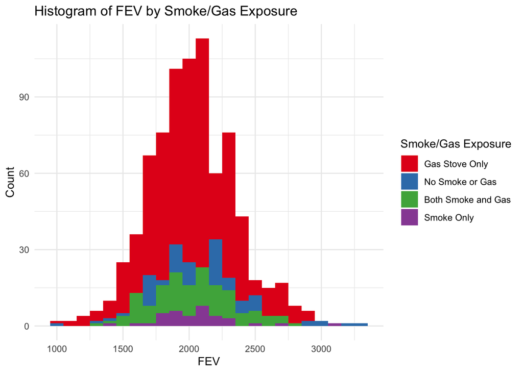

```r
# Convert the "smoke_gas_exposure" variable to a factor with desired levels
chs_total$smoke_gas_exposure <- factor(chs_total$smoke_gas_exposure, levels = c("Gas Stove Only", "No Smoke or Gas", "Both Smoke and Gas", "Smoke Only"))

# Create stacked histograms of FEV by smoke/gas exposure
histogram_smoke_gas <- ggplot(chs_total, aes(x = fev, fill = smoke_gas_exposure)) +
  geom_histogram(binwidth = 100, position = "identity") +
  labs(title = "Histogram of FEV by Smoke/Gas Exposure", x = "FEV", y = "Count") +
  scale_fill_brewer(palette = "Set1") +
  theme_minimal() +
  guides(fill = guide_legend(title = "Smoke/Gas Exposure"))

# Print the histogram
print(histogram_smoke_gas)
```

When looking at the histogram of FEV by Smoke/Gas exposure, we can notice that there are more individuals with smoke/gas exposure (as measured by presence of either or both of the gasstove and smoke variables) than individuals without smoke/gas exposure in the data set. However, all of the data appears to be fairly normally distributed.

## 3.Barchart of BMI by smoke/gas exposure.

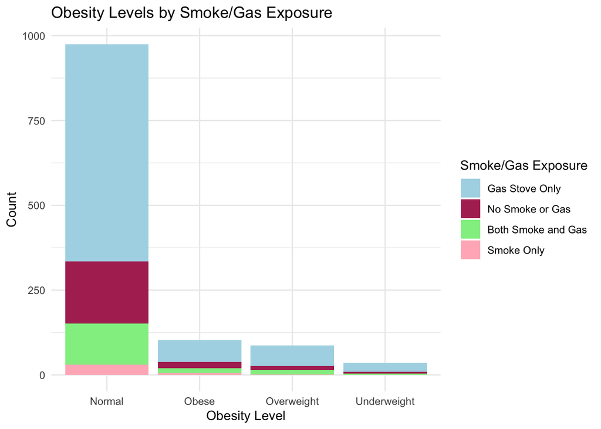

```r
library(ggplot2)

# Create a bar chart of obesity_level by smoke_gas_exposure
ggplot(chs_total, aes(x = obesity_level, fill = smoke_gas_exposure)) +
  geom_bar() +
  labs(title = "Obesity Levels by Smoke/Gas Exposure", x = "Obesity Level", y = "Count") +
  scale_fill_manual(values = c("Gas Stove Only"="lightblue", "No Smoke or Gas"="maroon", "Both Smoke and Gas"="lightgreen", "Smoke Only"="lightpink"), name = "Smoke/Gas Exposure") +
  theme_minimal()
```

Interpretation: I chose to use obesity level instead of BMI because BMI is a continuous variable and it didn’t seem to make sense to make a barchart. When looking at Obesity levels by Smoke/Gas exposure, most of the individuals have some sort of Smoke/Gas exposure, however there is not a clear relationship between Smoke/Gas exposure and obesity level. All of the groups seems to be evenly distributed.

## 4. Statistical summary graphs of FEV by BMI and FEV by smoke/gas exposure category.

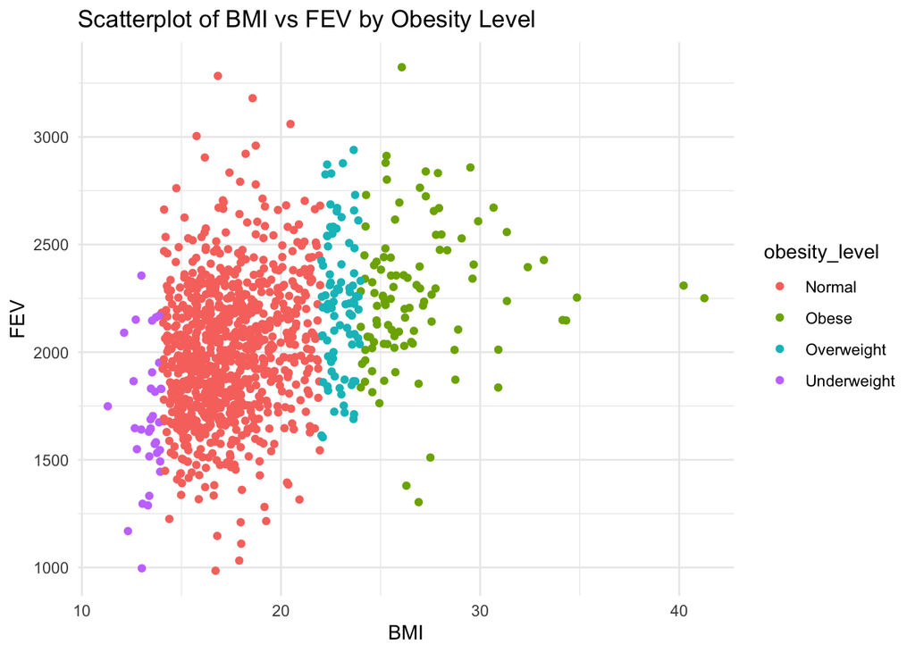

```r
# Create a scatterplot of BMI vs FEV, colored by obesity level
ggplot(chs_total, aes(x = bmi, y = fev, color = obesity_level)) +
  geom_point() +
  labs(title = "Scatterplot of BMI vs FEV by Obesity Level", x = "BMI", y = "FEV") +
  theme_minimal() +
  guides(fill = guide_legend(title = "Obesity Level"))
```

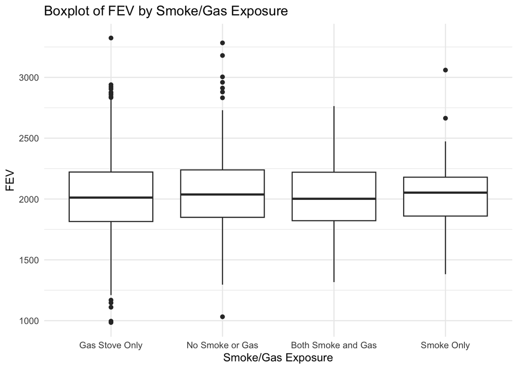

```r
# Create a boxplot of FEV by smoke/gas exposure category
ggplot(chs_total, aes(x = as.factor(smoke_gas_exposure), y = fev)) +
  geom_boxplot() +
  labs(title = "Boxplot of FEV by Smoke/Gas Exposure", x = "Smoke/Gas Exposure", y = "FEV") +
  scale_x_discrete(labels = c("0" = "No", "1" = "Yes")) +
  theme_minimal()
```

Interpretation: According to the scatterplot, it appears that there is a moderately positive correlation between BMI and FEV1. It seems that having a lower BMI means you have a lower FEV1, and vice versa. The boxplot of FEV by Smoke/Gas exposure indicates that there is not an association between Smoke/Gas exposure and FEV1.

## 5. A leaflet map showing the concentrations of PM2.5 mass in each of the CHS communities.

```r
# Load the necessary libraries
library(leaflet)
library(leaflet.extras)

# Create a Leaflet map with colored circle markers
leaflet(data = chs_total) %>%

  # Add tiles for the map background
  addProviderTiles("CartoDB.Positron") %>%

  # Add circle markers with varying colors based on PM2.5 mass
  addCircleMarkers(
    lng = ~lon,
    lat = ~lat,
    radius = ~pm25_mass,
    color = ~colorFactor("YlOrRd", domain = NULL)(pm25_mass),
    fillOpacity = 0.7,
    popup = ~paste("Community:", townname, "<br>PM2.5 Mass:", pm25_mass),
    label = ~pm25_mass
  ) %>%

  # Set map options
  setView(lng = -118.2437, lat = 34.0522, zoom = 7)
```

[interactive chart not shown]

Interpretation: According to the leaflet plot, the higher values of PM2.5 mass (the warmer colors and larger circle markers) are concentrated in the Los Angeles and San Bernardino area, probably due to these being large metropolitan areas with a lot of traffic and therefore pollutants.

## 6. Choose a visualization to examine whether PM2.5 mass is associated with FEV.

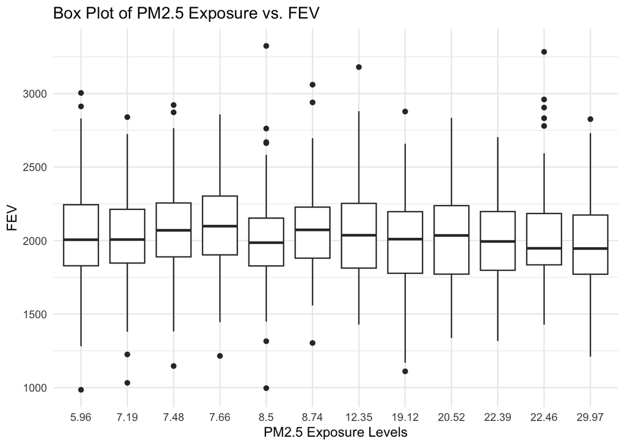

```r
ggplot(chs_total, aes(x = factor(pm25_mass), y = fev)) +
  geom_boxplot() +
  labs(title = "Box Plot of PM2.5 Exposure vs. FEV",
       x = "PM2.5 Exposure Levels",
       y = "FEV") +
  theme_minimal()
```

Interpretation: According to the averages of the box plots being very close to each other, it seems that there isn’t a strong relationship between FEV1 and PM2.5 exposure level. I chose to use a box plot to visualize because even though PM2.5 exposure levels are a continuous variable, there are only 12 unique values in this data set due to there only being 12 communities in the data set.